# F1 2017 Azerbaijan, Qualifying

Drivers progressed through the qualifying session as follows:

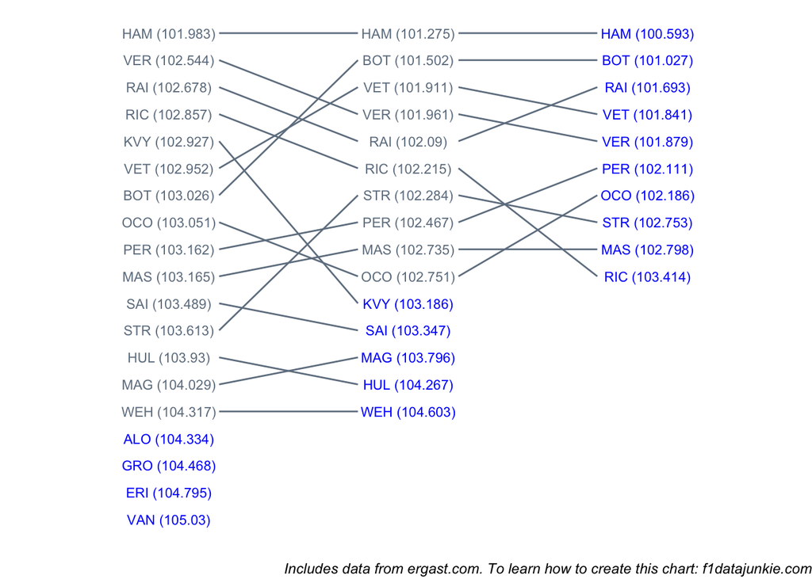

Going from Q1 to Q2:

- KVY failed to improve his time, recording 103.186 compared to 102.927 (0.259s slower)
- HUL failed to improve his time, recording 104.267 compared to 103.93 (0.337s slower)
- WEH failed to improve his time, recording 104.603 compared to 104.317 (0.286s slower)

Going from Q2 to Q3:

- STR failed to improve his time, recording 102.753 compared to 102.284 (0.469s slower)
- MAS failed to improve his time, recording 102.798 compared to 102.735 (0.063s slower)
- RIC failed to improve his time, recording 103.414 compared to 102.215 (1.199s slower)

Order change going from Q2 to Q3, along with laptime improvement (-ve is a better time in Q3)

```
##   driverName   imp1 driverName   imp2
## 1        RAI -0.397        VET -0.070
## 2        RAI -0.397        VER -0.082
## 3        PER -0.356        STR  0.469
## 4        PER -0.356        RIC  1.199
## 5        OCO -0.565        STR  0.469
## 6        OCO -0.565        MAS  0.063
## 7        OCO -0.565        RIC  1.199
## 8        STR  0.469        RIC  1.199
## 9        MAS  0.063        RIC  1.199
```

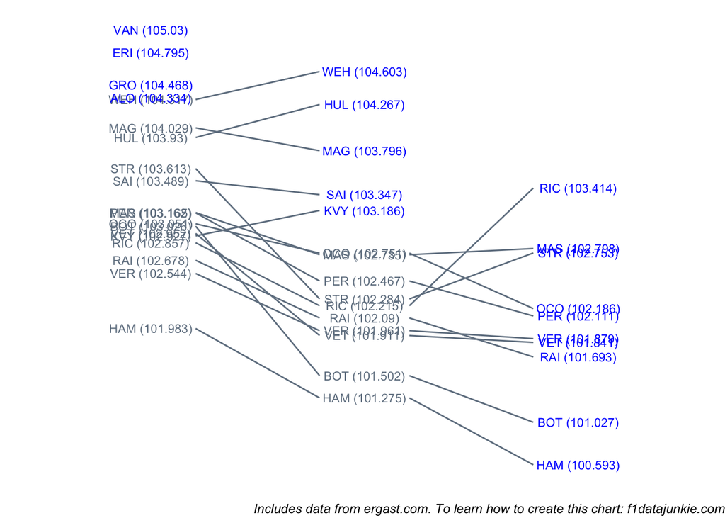

The official session results were recorded as follows:

| POS | DRIVER | Q1 | Q2 | Q3 |
| --- | --- | --- | --- | --- |
| 1 | HAM | 1:41.983 (1) | 1:41.275 (1) | 1:40.593 (1) |
| 2 | BOT | 1:43.026 (7) | 1:41.502 (2) | 1:41.027 (2) |
| 3 | RAI | 1:42.678 (3) | 1:42.090 (5) | 1:41.693 (3) |
| 4 | VET | 1:42.952 (6) | 1:41.911 (3) | 1:41.841 (4) |
| 5 | VER | 1:42.544 (2) | 1:41.961 (4) | 1:41.879 (5) |
| 6 | PER | 1:43.162 (9) | 1:42.467 (8) | 1:42.111 (6) |
| 7 | OCO | 1:43.051 (8) | 1:42.751 (10) | 1:42.186 (7) |
| 8 | STR | 1:43.613 (12) | 1:42.284 (7) | 1:42.753 (8) |
| 9 | MAS | 1:43.165 (10) | 1:42.735 (9) | 1:42.798 (9) |
| 10 | RIC | 1:42.857 (4) | 1:42.215 (6) | 1:43.414 (10) |
| 11 | KVY | 1:42.927 (5) | 1:43.186 (11) |  |
| 12 | SAI | 1:43.489 (11) | 1:43.347 (12) |  |
| 13 | MAG | 1:44.029 (14) | 1:43.796 (13) |  |
| 14 | HUL | 1:43.930 (13) | 1:44.267 (14) |  |
| 15 | WEH | 1:44.317 (15) | 1:44.603 (15) |  |
| 16 | ALO | 1:44.334 (16) |  |  |
| 17 | GRO | 1:44.468 (17) |  |  |
| 18 | ERI | 1:44.795 (18) |  |  |
| 19 | VAN | 1:45.030 (19) |  |  |

## Session Utilisation

Activity throughout the three qualification sessions took place as follows:

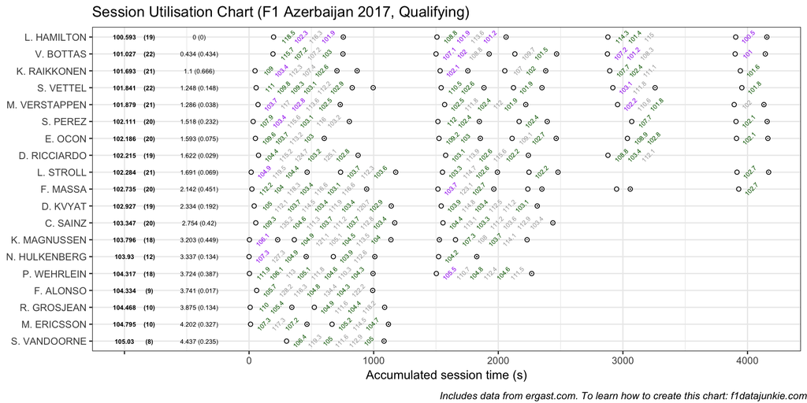

## Q1

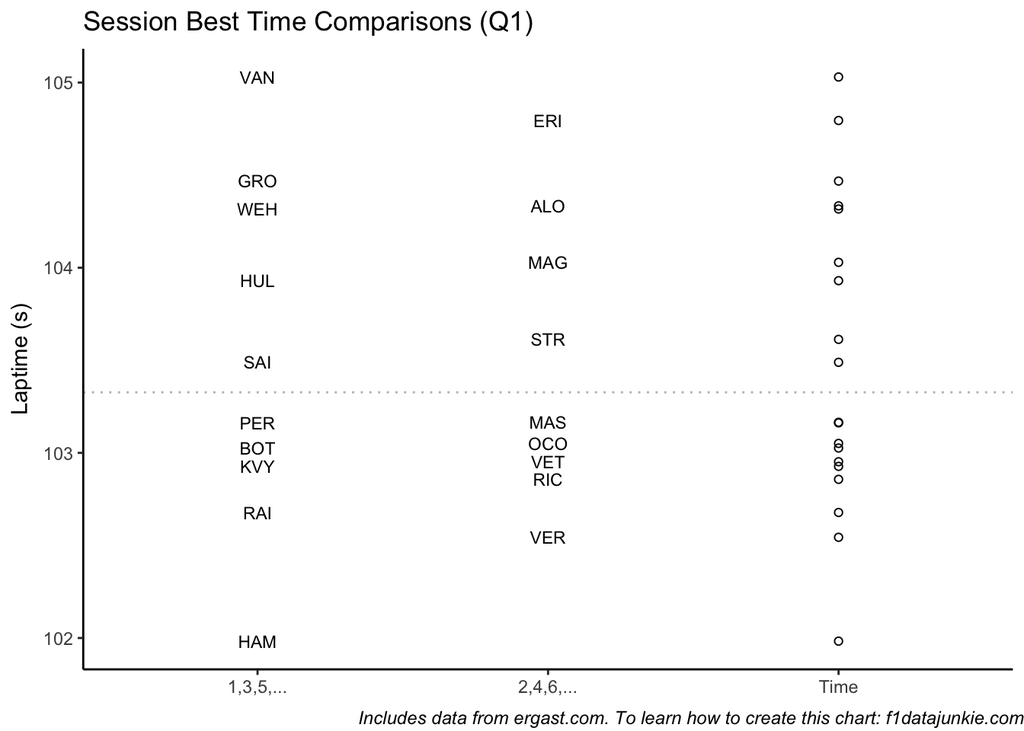

### Cut-off Time Evolution

The cut-off time in Q1 evolved as follows:

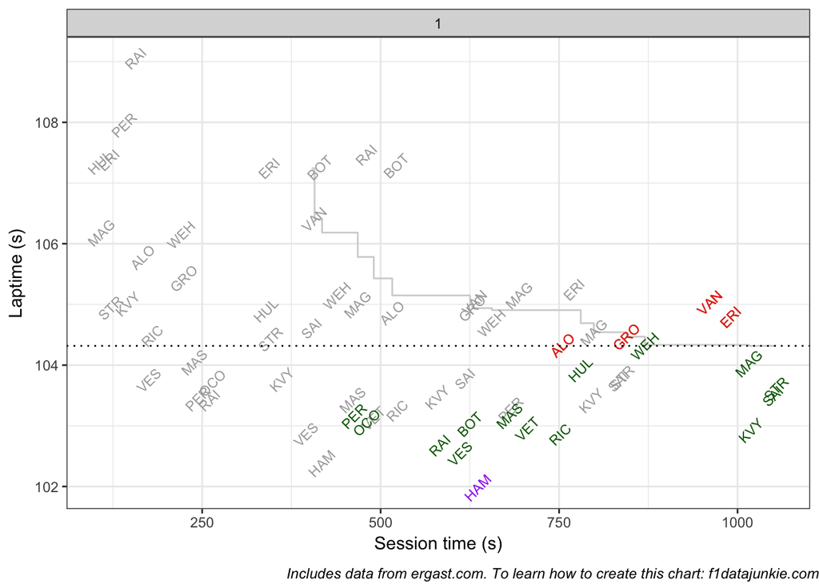

## Q2

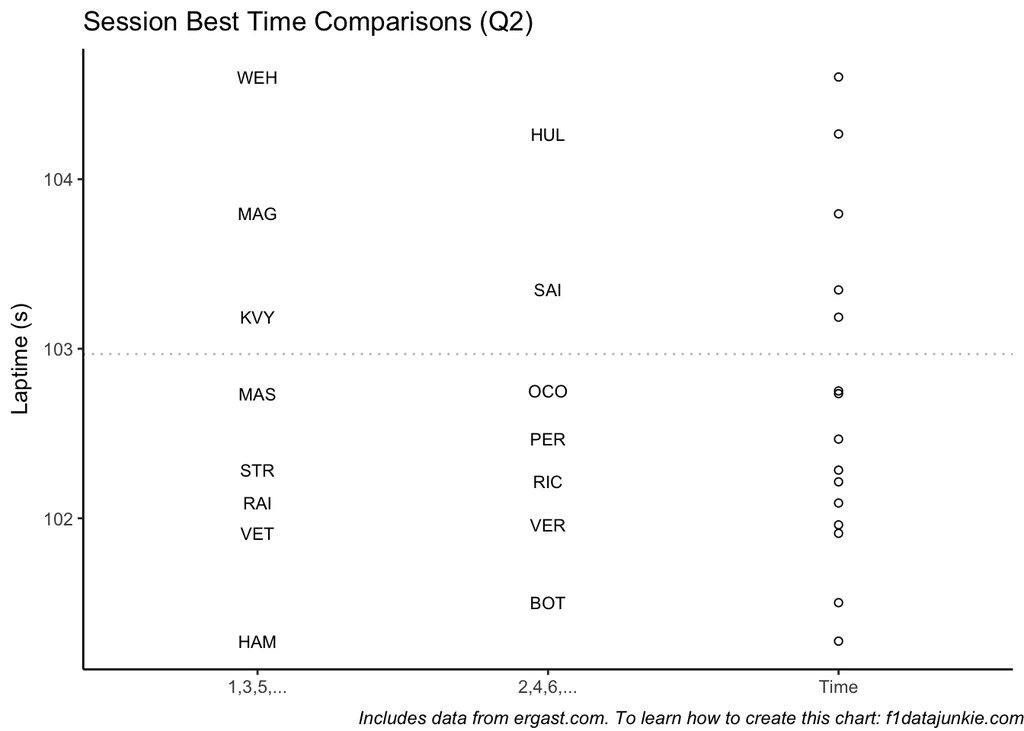

### Cut-off Time Evolution

The cut-off time in Q2 evolved as follows:

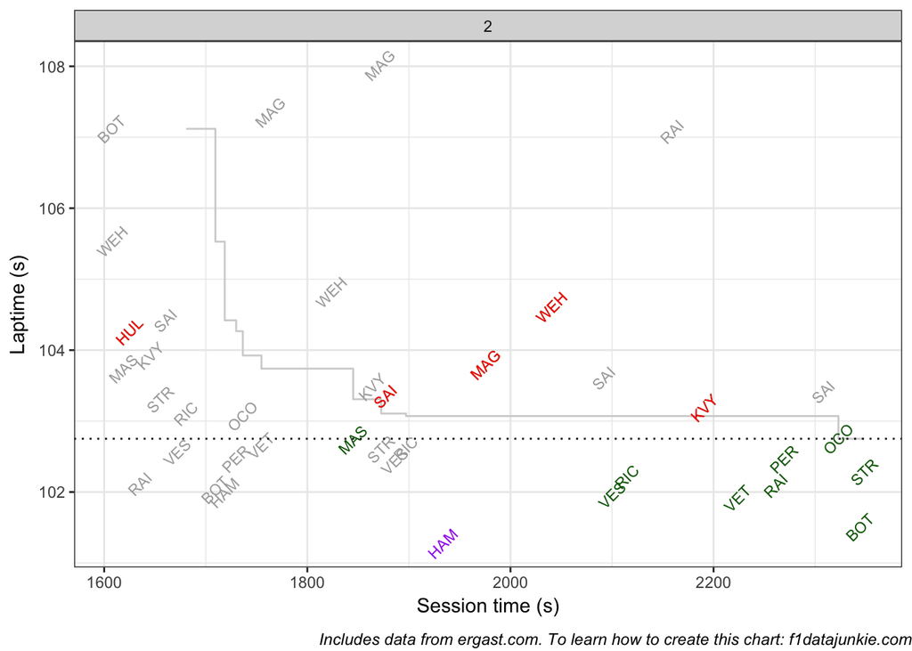

## Q3

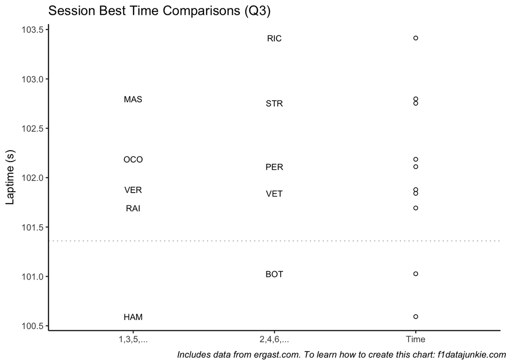

### Front Row Cut-off Time Evolution

The cut-off time in Q3 evolved as follows:

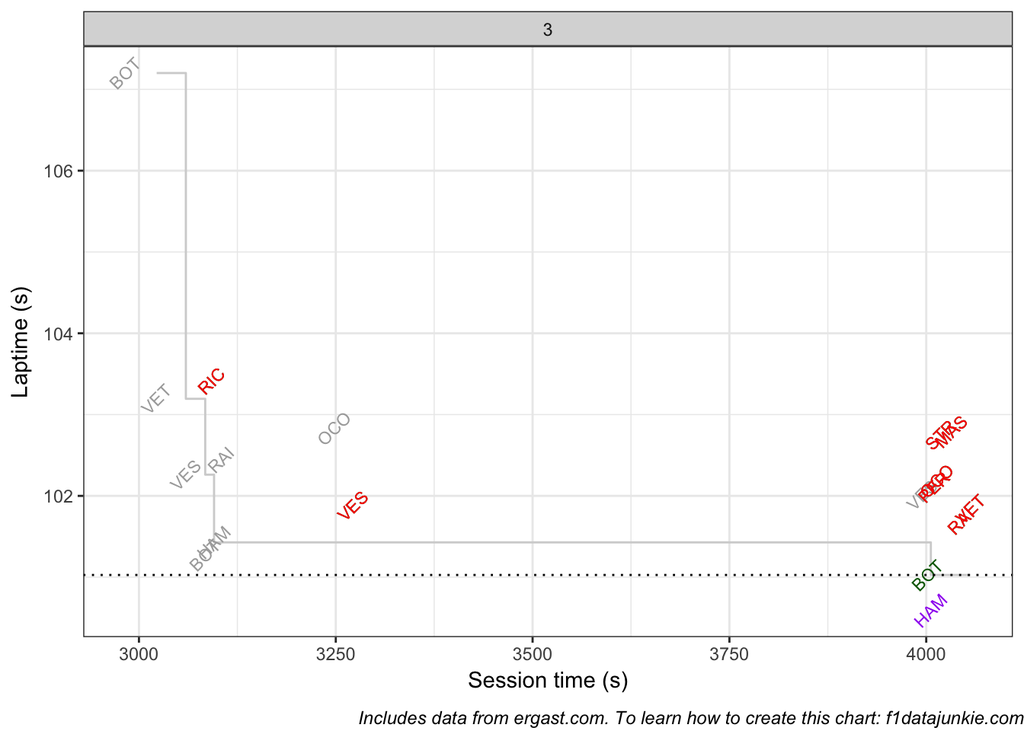

To learn how to wrangle F1 results and timing data to create charts like these, see f1datajunkie.com or [buy the *Wrangling F1 Data With R* book](https://leanpub.com/wranglingf1datawithr).